# Lecture 8 - Discriminant Function Analysis

the multivariate separation between groups

# Discriminant Function Analysis

- AKA linear discriminant analysis (LDA)
- Finds the multivariate axes that best separate groups
- Two major applications:
  - In combination with MANOVA to understand multivariate separation
  - Classification

# Uses of DFA

- Better interpretation of MANOVA results
- Classification

## Problem with our MANOVA

- We get many tests
  - Omnibus = multivariate separation between at least one pair of groups
  - Post-hoc:
    - Pairwise multivariate
    - Pairwise univariate
- Don’t get axes, scores, loadings etc. to interpret the multivariate differences
- DFA provides these

## Example: two of the iris variables

- The species differ significantly in centroid (MANOVA)
- How do they differ in a multivariate sense, on both PW and PL at the same time?

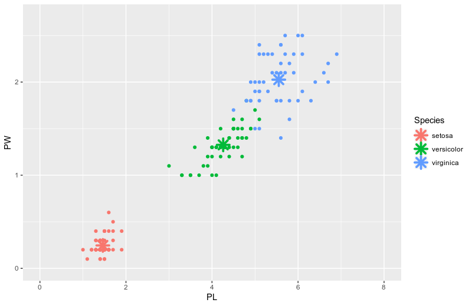

## What LDA does

- Finds canonical axes
- Positioned to best separate group centroids
- Points scored on LD axes
  - Loadings used to explain separation
  - Coefficients used to asses importance of predictors

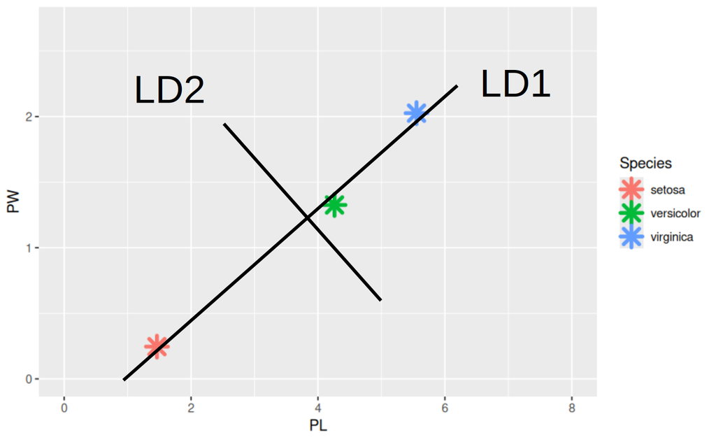

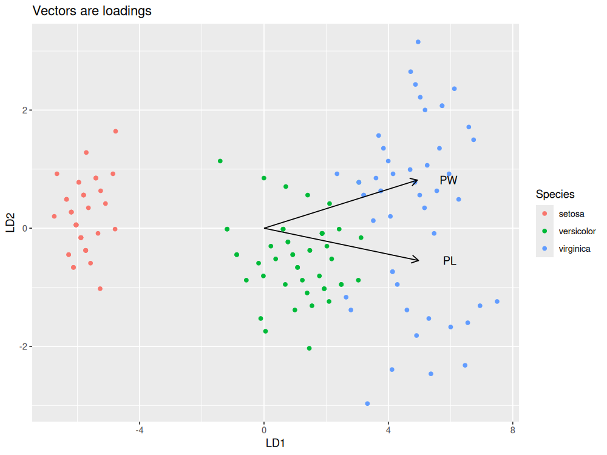

## Remember from MANOVA:

Between-groups SSCP (B)

```
             Petal.Width Petal.Length
Petal.Width     80.41333     186.7740
Petal.Length   186.77400     437.1028
```

Within-groups SSCP (W)

```
             Petal.Width Petal.Length
Petal.Width       6.1566       6.2718
Petal.Length      6.2718      27.2226
```

Between/Within SSCP - tested for significance

```
             Petal.Width Petal.Length
Petal.Width     7.934084     18.26754
Petal.Length    5.033061     11.84797
```

## How LDA works

- Conduct an eigenanalysis on the B/W matrix

```
Eigenanalysis of W-1B

$values
[1] 19.6773042  0.1047462

$vectors
           [,1]       [,2]
[1,] -0.8411826 -0.9191379
[2,] -0.5407512  0.3939360
```

- Eigenvalues = amount, variation in B/W explained
- Eigenvectors = direction, how the LDA axes run through the B/W matrix

## Again with all four variables

- Analytically no different than two
- Harder to visualize raw data, but can still plot two LDA axes with scores
- Only have three groups, why use four variables?
  - Unsure which separate the groups best
  - Understand the multivariate separation across all four used in MANOVA

## May need more than one axis

- Could be arranged like this ➙
- First axis separates group C from A/B
- Second axis needed to separate A from B

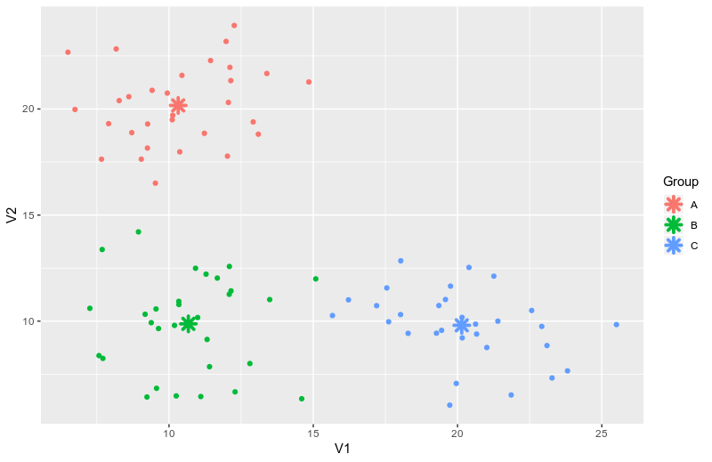

- LDA will give us as many axes as there are variables, or one less than the number of groups (k - 1), whichever is smaller

## LDA with four variables

```
Call:
lda(Species ~ Petal.Width + Petal.Length + Sepal.Width + Sepal.Length,
    data = iris)

Coefficients of linear discriminants:
                    LD1         LD2
Petal.Width  -2.8104603 -2.83918785
Petal.Length -2.2012117  0.93192121
Sepal.Width   1.5344731 -2.16452123
Sepal.Length  0.8293776 -0.02410215

Proportion of trace:
   LD1    LD2
0.9912 0.0088
```

- LD1 alone accounts for 99.12% of B/W matrix
- LD1 thus separates species, LD2 contributes little

## Interpreting LD axes: loadings

- Petal variables are most strongly correlated with LD1, so they separate the groups best

Loadings

```
                LD1   LD2
Sepal.Length -0.792 0.218
Sepal.Width   0.531 0.758
Petal.Length -0.985 0.046
Petal.Width  -0.973 0.223
```

- SL is moderately strongly correlated, same direction as petal variables
- SW is weakest, more strongly correlated with LD2

## Interpreting LD axes: communalities

- Squaring the loadings = communalities
- Proportion of variance in measured variables explained by LD

Communalities: loadings<sup>2</sup>

```
               LD1   LD2
Sepal.Length 0.627 0.047
Sepal.Width  0.282 0.575
Petal.Length 0.970 0.002
Petal.Width  0.946 0.050
```

- PL and PW very high, SL moderate
- Don’t sum to 100% now (fewer LD axes than variables)

## Coefficients vs. loadings

Loadings

|  | LD1 | LD2 |
| --- | --- | --- |
| Petal.Width | -0.973 | -0.223 |
| Petal.Length | -0.985 | -0.046 |
| Sepal.Width | 0.531 | -0.758 |
| Sepal.Length | -0.792 | -0.218 |

Coefficients

|  | LD1 | LD2 |
| --- | --- | --- |
| Petal.Width | -2.810 | -2.839 |
| Petal.Length | -2.201 | 0.932 |
| Sepal.Width | 1.534 | -2.165 |
| Sepal.Length | 0.829 | -0.024 |

How could that be?

## Positive correlation, negative coefficient

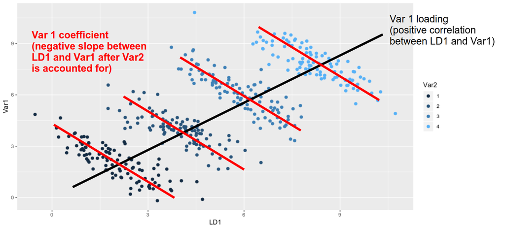

## We see this in SL

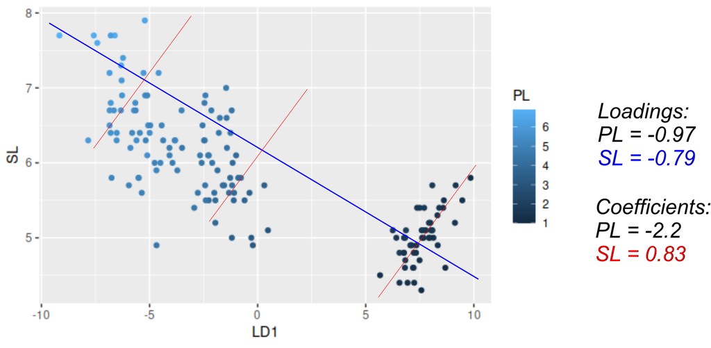

## LDA biplots - with loadings or coefficients

Arrows are coefficients

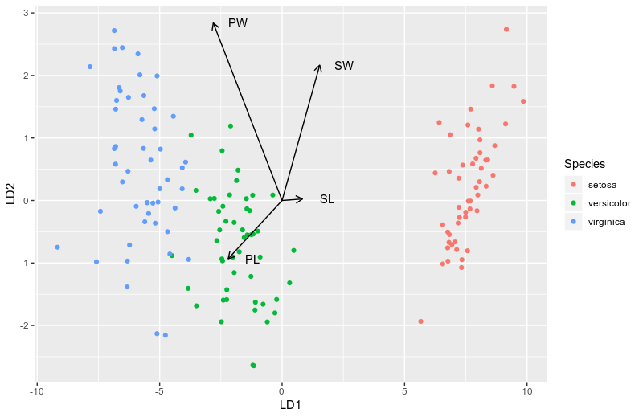

Useful for identifying the variables that contribute most to group separation

Arrows are loadings

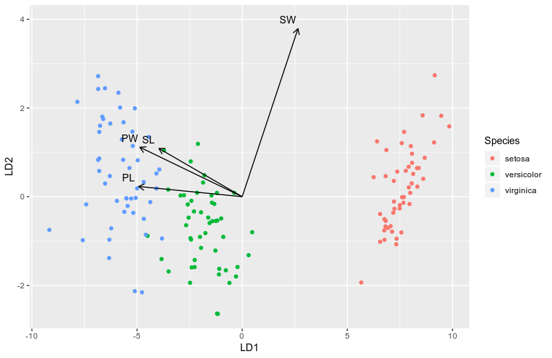

Useful for interpreting what data points look like in each group

# Uses of DFA

- Better interpretation of MANOVA results
- Classification

## Classification: grouping

- Classification = assigning observations to groups
- Two primary reasons to do this with LDA:
  - Assignment of unknowns to groups
    - e.g. Abledu et al. - classify sex from footprint measurements
    - Need to validate with knowns first
  - Measure amount of overlap between groups

## Abledu et al. 2015

- Your project paper
- Developed an LDA for classification
  - Measured sample of people with known sexes
  - Used LDA to find a function that best separated the sexes
- Validated - checked that it worked on footprints with known sex

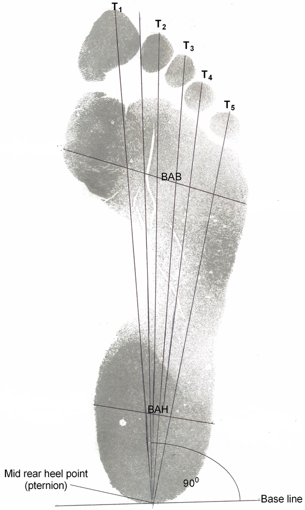

- Ready for use to assign sex from a footprint

## Their LDA

- Left discriminant function:  
  0.866 T5 + 0.741 BAH
- Midpoint between M/F means:  
  T5 = 20.46, BAH = 5.37
  - Midpoint score = 21.69
- Measure the T5 and BAH for any left footprint, plug it into the equation to get a score
  - If score is < 21.69 predict female, if score is > 21.69 predict male
- Right discriminant function:  
  0.342 T1 + 0.856 BAB + 0.748 BAH
- Midpoint between M/F means:  
  T1 = 24.19, BAB = 9.28, BAH = 5.36
  - Midpoint score = 20.234
- Measure T1, BAB, BAH for any right footprint, plug it into the equation to get a score
  - If score is < 20.234 predict female, if score is > 20.234 predict male

## Statistical significance vs. separation

- Both examples on the right have significantly different centroids
- There is almost no overlap in data values for the irises
- There is extensive overlap for Bumpas’ sparrows
- Which LDA will be better at classification?

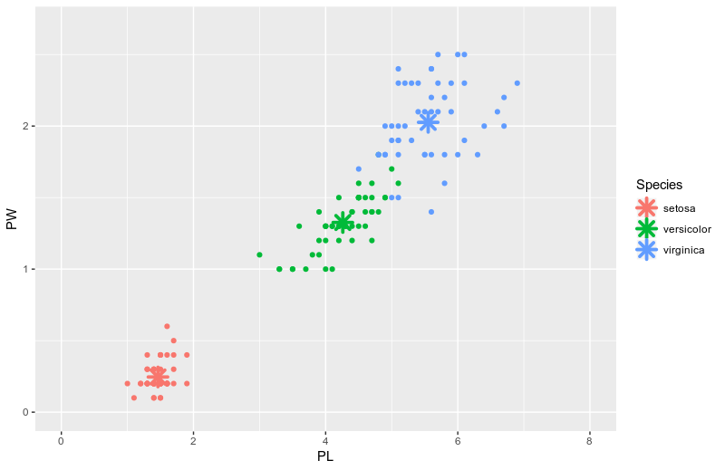

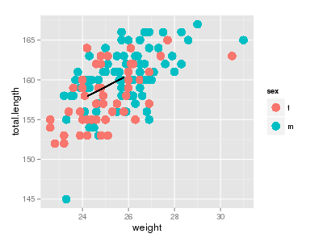

## Overlap in scores between species

- The more non-overlapping the data are between groups the better the LDA will do at assigning to groups
- Each iris is scored on LD1, histogram drawn by known group membership
- Setosa very different, versicolor and virginica overlap slightly

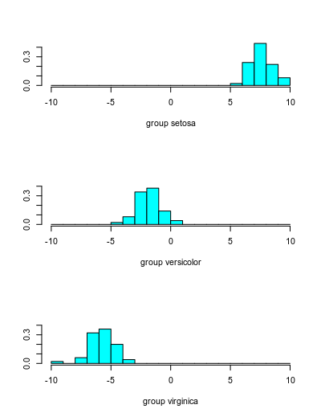

## Classifying based on LD1 scores

- Vertical lines at midpoints between adjacent species
- Every setosa observation closest to setosa mean, so 100% get classified correctly
- A little overlap between virginica and versicolor, so some end up closer to the wrong mean and get mis-classified

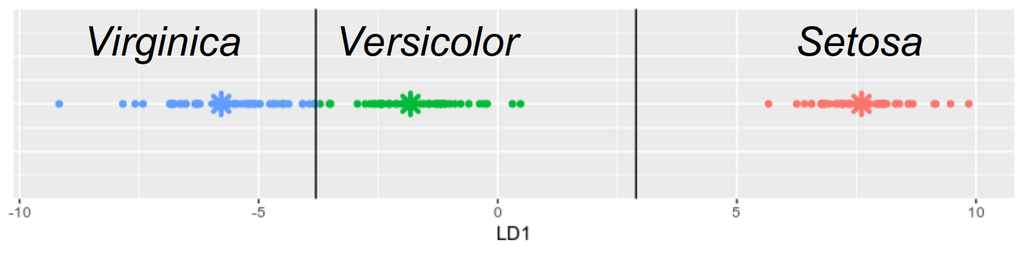

## Scoring an unknown

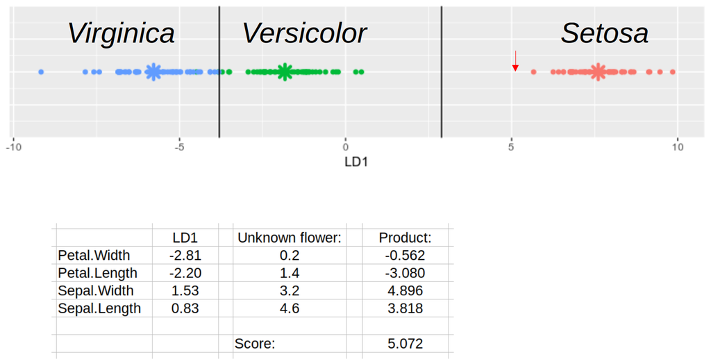

Classify as a setosa

## When groups overlap extensively

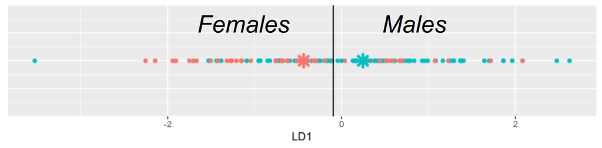

Many males closer to female mean, many females closer to male mean  
Many more classification errors as a result

## Prediction based on probabilities

- Using scores works fine with a single LD axis
- If more than one axis needed then using probability is better
  - Probability of group membership is calculated based on distances from centroids across all the LD axes
  - Assign observations to the group with the highest probability

## Probability for iris data

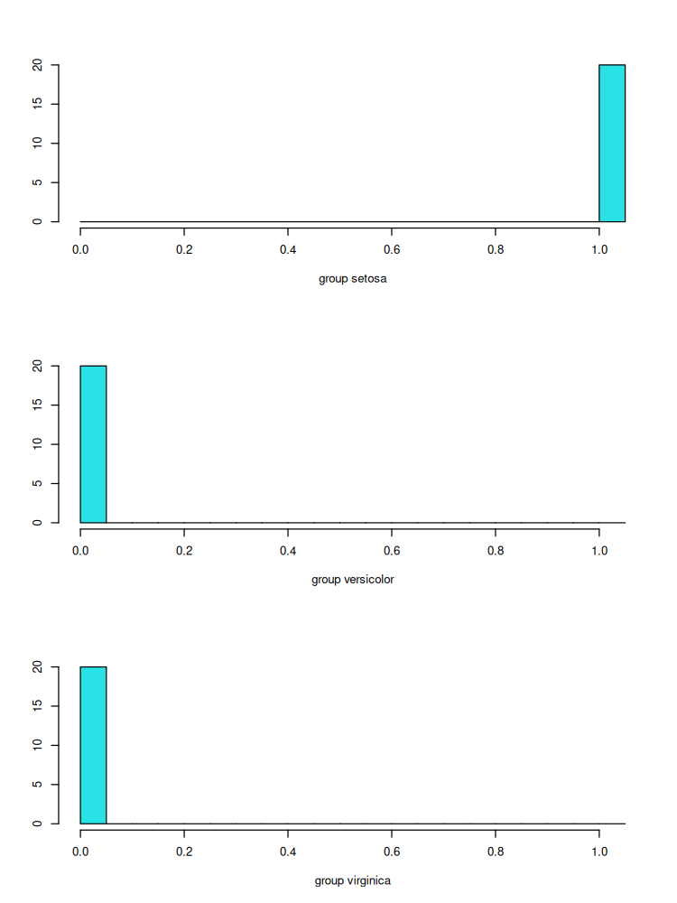

Probability setosa

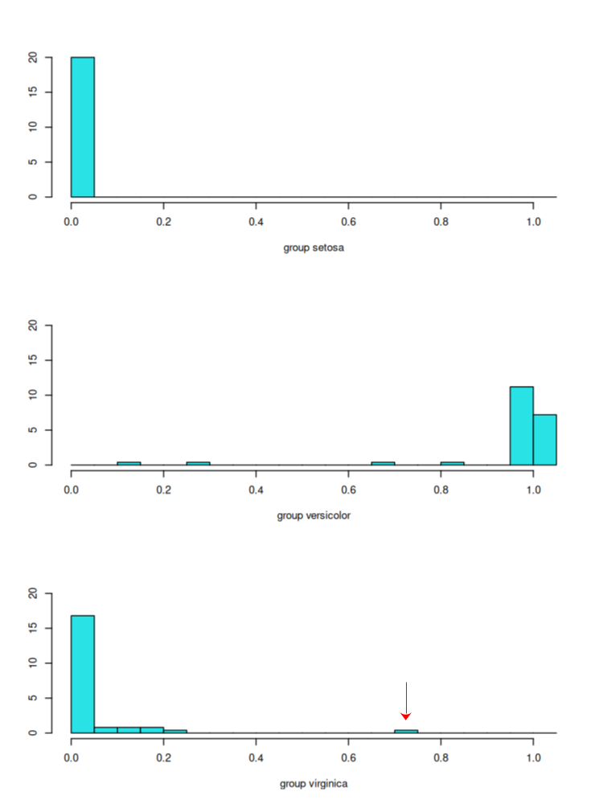

Probability versicolor

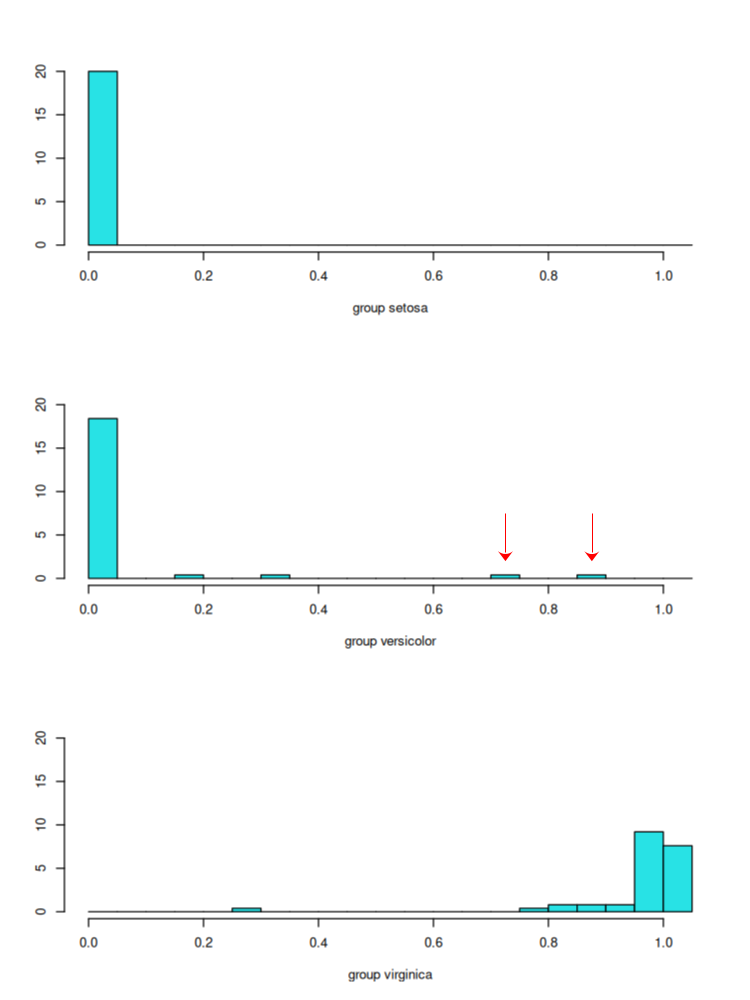

Probability virginica

Just a few have a higher probability of being a different species than they are

## The confusion matrix

- When we’re working with knowns:
  - We know which observations are correctly classified
  - We know which are incorrectly classified
- Make a “confusion” matrix with:
  - Known group in the rows
  - Predicted group in the columns
- We can count up all the combinations to see how well the prediction works

## Cunfusion matrices: iris and sparrows

As expected, 100% of setosa were correctly classified.

Two versicolor predicted to be virginica

One virginica predicted to be versicolor

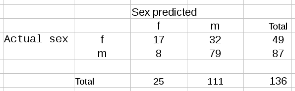

Sparrow confusion matrix

Many more mis-classifications

32 females predicted to be male (more than predicted f)

8 males predicted to be female

## Cohen’s kappa - agreement

- Some amount of correct classification happens by chance
- Cohen’s kappa ($\kappa$) measures agreement in excess of chance
  $$\kappa = \frac {\text {Correct} - \text {Expected correct}}{\text {Trials} - \text {Expected correct}}$$
- Range of values from 0 to 1, with values > 0.7 considered good (closer to 1 the better)

## Kappa for iris, sparrows

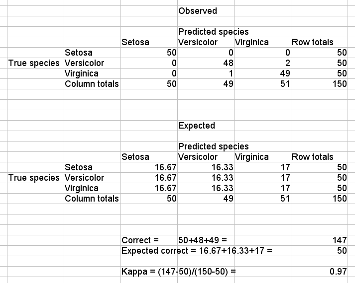

Irises

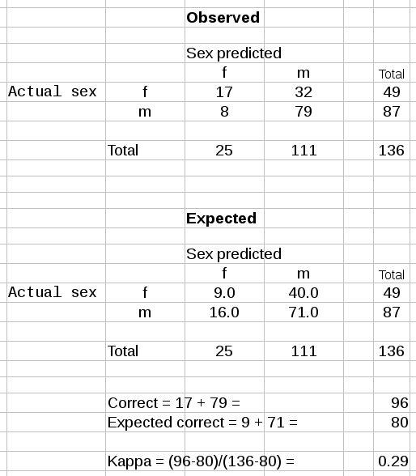

Sparrows

# Fine points, tweaks

- Prior probabilities
- Simplifying the LDA

## Do we want unequal priors?

- Prior probability = the probability of group membership before the LDA is conducted
- Default is to set priors equal to group sample size
  - Assumes sample size proportional to group size
  - If 90% of observations are group A, then the prior probability an observation will be A is 0.9, prior for B is 10%
  - This can improve classification success
- Can set them to be equal, even if sample/group size is different
  - Only the discriminant function affects predicted group membership

## Unequal priors - change the cutoff between groups

Black lines = midpoints between groups, Red lines = increased prior of versicolor, causes more points to be classified as versicolor

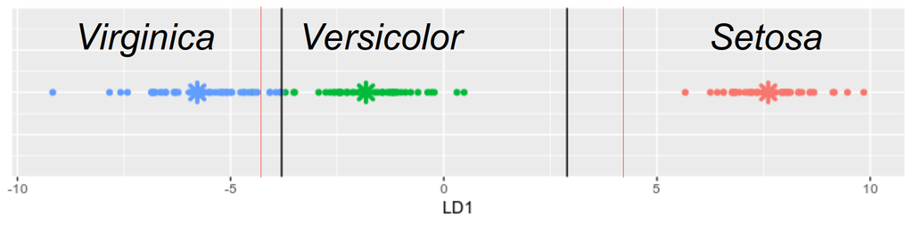

Unequal priors change the chance of being in each group

## Finding the best, simplest LDA

- Including predictors that don’t improve classification success is a bad idea
  - Increases uncertainty in estimates for the important predictors
  - Makes LDA work less well on new observations
- We can use the LDA coefficients to help pick variables to drop
- If dropping them does not reduce classification success they aren’t needed

## Biplot of coefficients

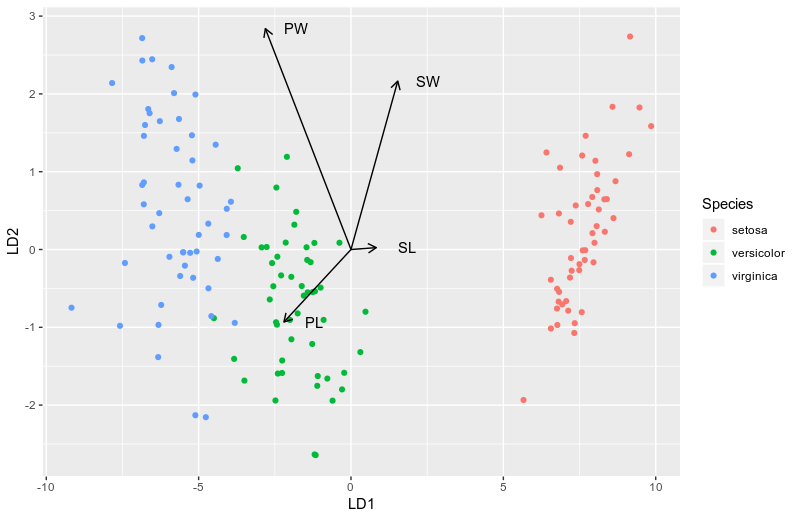

All four variables included

SL has very little independent contribution to LD1 - remove it

## Biplot of coefficients, confusion

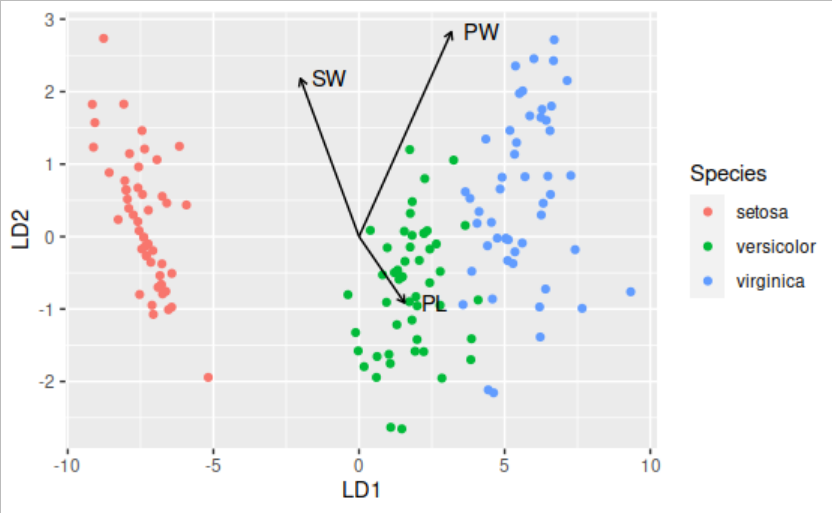

Re-run with only SW, PL and PW

## Biplot of coefficients, confusion

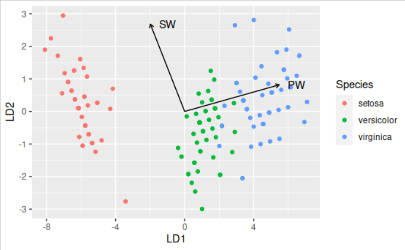

Re-run with only SW and PW

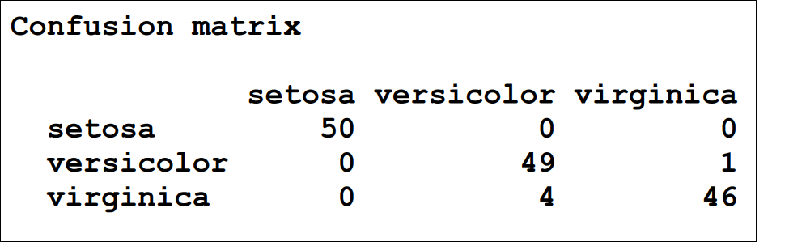

Confusion matrix without SL or PL

Confusion increasing - dropping SL was good, but dropping PL was too much

# Why not just do a PCA?

- We learned we can:
  - Do a PCA
  - Name the latent variables
  - Use them as responses
  - Interpret the differences
- Why bother with DFA?

# Wrap up

- DFA (LDA) is used to:
  - Help understand the multivariate separation between groups identified with a MANOVA
  - Classify unknowns based on measured variables
- Confusion matrices are used to:
  - Assess how well classification works
  - Measure overlap in data values between groups
- Can simplify models to see if they still work as well - prefer simple